# PalaeoOpen ordination exercise

Author

Gavin L. Simpson

## Ordinaton

In this exercise you’ll explore a multiproxy data set from Prášilské jezero, a glacial cirque lake, Czechia.

### Getting started

As I haven’t taken the training for the *neotoma2* R package, I downloaded the CSV files from the Neotoma Explorer. This will require us to do some data wrangling and also to work around a bug in the way the Explorer writes the CSV files.

We’ll begin by installing some packages before we proceed to the data wrangling.

#### Installing required packages

We need a few packages. If you have all of these packages installed, please make sure they are updated to the latest version by running `update.packages(ask = FALSE, checkBuilt = TRUE)`.

```r
inst_pkgs <- c(
  "here", "vegan", "cocorresp", "readr", "dplyr", "tidyr", "stringr",
  "janitor", "tidyverse"
)
```

You can use the newer *pak* package to install the packages and relevant dependencies. This is useful for installing from GitHub repositories etc. If you just want to use the plain base R option, skip to Option 2.

##### Option 1

First, check if you have *pak* installed; the code below tries to load the package and if it isn’t installed, it tries to install it.

```r
if (!requireNamespace("pak", quietly = TRUE)) {install.packages("pak")}
```

Assuming that worked successfully, you can now use *pak* to install the required packages:

```r
pak::pak(inst_pkgs)
```

or

##### Option 2

This uses the standard installer to install the required packages

```r
install.packages(inst_pkgs)
```

#### Loading packages for use in exercise

Having installed the packages, we need to load them into our R session to use them. Here I am just loading some of the packages we installed earlier.

```r
pkgs <- inst_pkgs[1:7] # only load some now
vapply(
  pkgs,
  FUN = library,
  FUN.VALUE = logical(1),
  character.only = TRUE,
  logical.return = TRUE
)
## here() starts at /Users/gavin/work/projects/EU/palaeopen/meetings/sofia-2026/teaching
## Loading required package: permute
##
## Attaching package: 'dplyr'
## The following objects are masked from 'package:stats':
##
##     filter, lag
## The following objects are masked from 'package:base':
##
##     intersect, setdiff, setequal, union
##      here     vegan cocorresp     readr     dplyr     tidyr   stringr
##      TRUE      TRUE      TRUE      TRUE      TRUE      TRUE      TRUE
```

`vapply()` is an R function that will interate over the elements of `pkgs` and call the `library()` function to load each of the selected packages.

#### Load the data

Buckle up; you’re about to get your hands dirty with a lot of data wrangling code. Please don’t type out all of this stuff; use the copy icon in the upper-right of each code block.

We will load the diatom, pollen, and chironomid data from the lake.

##### Diatoms

To load the diatom data, we read them from the CSV file I downloaded from Neotoma using the Explorer, and remove some of the columns that we don’t need.

```r
diatoms <- read_csv(
  here("00-data/dataset55585_site26991.csv")
) |>
  select(!c(group, element, units, context))
## Rows: 218 Columns: 41
## ── Column specification ────────────────────────────────────────────────────────
## Delimiter: ","
## chr (40): name, group, element, units, S567723, S567734, S567743, S567749, S...
## lgl  (1): context
##
## ℹ Use `spec()` to retrieve the full column specification for this data.
## ℹ Specify the column types or set `show_col_types = FALSE` to quiet this message.
```

Print the data we downloaded; you should note that this is stored as a *tibble*, a fancy data frame, and that only 10 rows are shown, and only as many columns as can be fitted into the width of the R console.

```r
diatoms
## # A tibble: 218 × 37
##    name  S567723 S567734 S567743 S567749 S567755 S567728 S567738 S567748 S567725
##    <chr> <chr>   <chr>   <chr>   <chr>   <chr>   <chr>   <chr>   <chr>   <chr>
##  1 Anal… <NA>    <NA>    <NA>    <NA>    <NA>    <NA>    <NA>    <NA>    <NA>
##  2 Depth 1490.25 1550.25 1610.25 1640.25 1698.25 1505.25 1560.25 1630.25 1525.25
##  3 Thic… 0.5     0.5     0.5     0.5     0.5     0.5     0.5     0.5     0.5
##  4 Samp… <NA>    <NA>    <NA>    <NA>    <NA>    <NA>    <NA>    <NA>    <NA>
##  5 Samp… 567723  567734  567743  567749  567755  567728  567738  567748  567725
##  6 Upda… --/207… --/325… --/701… --/845… --/114… --/827… --/382… --/798… --/192…
##  7 Achn… <NA>    <NA>    <NA>    <NA>    <NA>    <NA>    <NA>    <NA>    <NA>
##  8 Achn… <NA>    <NA>    <NA>    5       <NA>    <NA>    <NA>    <NA>    <NA>
##  9 Achn… <NA>    1       3       1       <NA>    <NA>    <NA>    <NA>    <NA>
## 10 Achn… <NA>    <NA>    <NA>    <NA>    <NA>    <NA>    <NA>    <NA>    <NA>
## # ℹ 208 more rows
## # ℹ 27 more variables: S567732 <chr>, S567741 <chr>, S567751 <chr>,
## #   S567726 <chr>, S567735 <chr>, S567747 <chr>, S567729 <chr>, S567733 <chr>,
## #   S567744 <chr>, S567754 <chr>, S567721 <chr>, S567731 <chr>, S567740 <chr>,
## #   S567752 <chr>, S567720 <chr>, S567730 <chr>, S567737 <chr>, S567746 <chr>,
## #   S567722 <chr>, S567742 <chr>, S567753 <chr>, S567724 <chr>, S567736 <chr>,
## #   S567745 <chr>, S567727 <chr>, S567739 <chr>, S567750 <chr>
```

Currently, the data are in a wide format, but are transposed relative to the requirements of *vegan* and also of the math. We use `pivot_longer()` to reshape the data into a long format.

```r
diat_long <- diatoms |>
  pivot_longer(
    cols = !name,
    names_to = "identifier",
    values_to = "value"
  )
```

Some of the data in the file is metadata; we will extract these variables into their own object to allow us to create an object that only contains the diatom counts.

```r
diat_meta <- diat_long |>
  filter(                 # extract the named variables
    name %in% c(
      "AnalysisUnitName", "Depth", "Thickness", "Sample Name", "Sample ID",
      "Updated Carter et al. 2018"
    )
  ) |>
  mutate(                 # change the names of some variables for ease of use
    name = replace_values(
      name,
      "Updated Carter et al. 2018" ~ "calibrated_age",
      "Depth" ~ "depth_cm",
      "Thickness" ~ "thickness_cm",
    )
  ) |>              # make these data wide, one column per variable again
  pivot_wider(
    id_cols = identifier,
    names_from = name,
    values_from = value
  ) |>
  janitor::clean_names() # clean the names for ease of use
```

A final step for the metadata is remove some redundant columns, and then to clean up the calibrated age column, which is formatted `lower/point/upper`, but if the uncertainty interval is missing, this becomes `--/point/--`. We will just extract the point age estimate here, which requires us to strip out the `--/` and `/--` parts of the string and then convert the variables to numeric format.

```r
diat_meta <- diat_meta |>
  select(
    !c(analysis_unit_name, sample_name)
  ) |>
  mutate(
    calibrated_age = str_replace( # remove the lower interval
      calibrated_age, "^--/", ""
    ),
    calibrated_age = str_replace(
      calibrated_age, "/--$", ""  # remove the upper interval
    ),
    across(                       # convert some to numeric
      c(depth_cm, thickness_cm, calibrated_age),
      .fns = ~ as.numeric(.x)
    )
  ) |>
  arrange(depth_cm)               # order by depth
```

Take a look at what you have created

```r
diat_meta
## # A tibble: 36 × 5
##    identifier depth_cm thickness_cm sample_id calibrated_age
##    <chr>         <dbl>        <dbl> <chr>              <dbl>
##  1 S567720       1478.          1   567720               -60
##  2 S567721       1486.          1   567721                60
##  3 S567723       1490.          0.5 567723               207
##  4 S567724       1495.          0.5 567724               379
##  5 S567722       1500.          0.5 567722               578
##  6 S567728       1505.          0.5 567728               827
##  7 S567727       1510.          0.5 567727              1097
##  8 S567729       1517.          0.5 567729              1506
##  9 S567726       1520.          0.5 567726              1670
## 10 S567725       1525.          0.5 567725              1928
## # ℹ 26 more rows
```

Now we return to the diatom data which is in the long format. First we remove the metadata columns we just handled

```r
diat_long <- diat_long |>
  filter_out(
    name %in% c(
      "AnalysisUnitName", "Depth", "Thickness", "Sample Name", "Sample ID",
      "Updated Carter et al. 2018"
    )
  )
```

Next, we convert the `value` column to numeric and replace `NA` with 0 count, before reshaping the data to the wide format again (`pivot_wider()`), but now with the taxa as the columns, not the samples.

```r
diat_wide <- diat_long |>
  mutate(
    value = as.numeric(value),
    value = replace_na(value, replace = 0)
  ) |>
  pivot_wider(           # pivot! long --> wide
    id_cols = identifier,
    names_from = name,
    values_from = value
  ) |>
  janitor::clean_names() # clean variables names
```

Now we have the data in a wide format, we need to et the data in a common order. Here I temporarily join the data with the metatdata (`diat_meta()`), arrnage by `depth_cm` and then remove the none taxa columns

```r
diat_wide <- diat_wide |>
  left_join(
    diat_meta, by = "identifier"
  ) |>
  arrange(depth_cm) |>
  select(identifier:aff_nupela)
```

Finally, *vegan* is old-school and sticks closely to the underlying math. This means we need to have a data frame with *only* the species counts, meaning that the sample labels need to be stored as the row names. This is at odds with the *tidyverse* principles, which would like to have any usable information as an actual variable in the data frame and row names are outlawed. Here, we use a convenience function from the *tibble* package to handle this issue for us:

```r
diat_df <- diat_wide |>
  tibble::column_to_rownames("identifier")
```

Now that we have complete the data wrangling for the diatoms, we should sit back and take a small break and look at what we have created (well, a bit of it); do **not** type `diat_df` to print the entire thing

```r
diat_df[1:6, 1:6]
##         achnanthidium_cf_a_minutissimum achnanthidium_linearioide
## S567720                               0                         0
## S567721                               0                         0
## S567723                               0                         0
## S567724                               0                         0
## S567722                               0                         0
## S567728                               0                         0
##         achnanthidium_minutissimum_s_l achnanthidium_spp adlafia_bryophila
## S567720                              0                 0                 0
## S567721                              0                 0                 0
## S567723                              0                 0                 0
## S567724                              0                 0                 0
## S567722                              0                 0                 0
## S567728                              0                 0                 0
##         adlafia_spp
## S567720           0
## S567721           0
## S567723           0
## S567724           0
## S567722           0
## S567728           0
```

##### Chironomids

Now we can repeate the steps for the chironomids. This is mostly the same as for the diatoms.

```r
chiros <- read_csv(
  here("00-data/dataset55586_site26991.csv")
) |>
  select(!c(group, element, units, context))
## Rows: 45 Columns: 32
## ── Column specification ────────────────────────────────────────────────────────
## Delimiter: ","
## chr (31): name, group, element, units, S567761, S567782, S567763, S567770, S...
## lgl  (1): context
##
## ℹ Use `spec()` to retrieve the full column specification for this data.
## ℹ Specify the column types or set `show_col_types = FALSE` to quiet this message.
```

```r
chiro_long <- chiros |>
  pivot_longer(
    cols = !name,
    names_to = "identifier",
    values_to = "value"
  )
```

```r
chiro_meta <- chiro_long |>
  filter(
    name %in% c(
      "AnalysisUnitName", "Depth", "Thickness", "Sample Name", "Sample ID",
      "Updated Carter et al. 2018"
    )
  ) |>
  mutate(
    name = replace_values(
      name,
      "Updated Carter et al. 2018" ~ "calibrated_age",
      "Depth" ~ "depth_cm",
      "Thickness" ~ "thickness_cm",
    )
  ) |>
  pivot_wider(
    id_cols = identifier,
    names_from = name,
    values_from = value
  ) |>
  janitor::clean_names()
```

```r
chiro_meta <- chiro_meta |>
  select(
    !c(analysis_unit_name, sample_name)
  ) |>
  mutate(
    calibrated_age = str_replace(
      calibrated_age, "^--/", ""
    ),
    calibrated_age = str_replace(
      calibrated_age, "/--$", ""
    ),
    across(
      c(depth_cm, thickness_cm, calibrated_age),
      .fns = ~ as.numeric(.x)
    )
  ) |>
  arrange(depth_cm)
```

```r
chiro_long <- chiro_long |>
  filter_out(
    name %in% c(
      "AnalysisUnitName", "Depth", "Thickness", "Sample Name", "Sample ID",
      "Updated Carter et al. 2018"
    )
  )
```

```r
chiro_wide <- chiro_long |>
  mutate(
    value = as.numeric(value),
    value = replace_na(value, replace = 0)
  ) |>
  pivot_wider(
    id_cols = identifier,
    names_from = name,
    values_from = value
  ) |>
  janitor::clean_names()
```

```r
chiro_wide <- chiro_wide |>
  left_join(
    chiro_meta, by = "identifier"
  ) |>
  arrange(depth_cm) |>
  select(identifier:zavrelimyia_type_a)
```

```r
chiro_meta <- chiro_meta |>
  left_join(
    chiro_wide |> select(c(identifier, sample_quantity))
  ) |>
  rename(
    sample_qty_ml = sample_quantity
  )
## Joining with `by = join_by(identifier)`
```

```r
chiro_wide <- chiro_wide |>
  select(!sample_quantity)
chiro_df <- chiro_wide |>
  tibble::column_to_rownames("identifier")
```

##### Pollen

The pollen data can also be loaded using alomst the same code. A couple of extra steps are needed however as the data are in a slightly different format and contain things we don’t want.

```r
pollen <- read_csv(
  here("00-data/dataset47520_site26991.csv")
) |>
  filter(is.na(element) | element == "pollen") |> # only take the pollen
  select(!c(group, element, units, context))
## Rows: 124 Columns: 201
## ── Column specification ────────────────────────────────────────────────────────
## Delimiter: ","
## chr (200): name, group, element, units, S433835, S433836, S433837, S433838, ...
## lgl   (1): context
##
## ℹ Use `spec()` to retrieve the full column specification for this data.
## ℹ Specify the column types or set `show_col_types = FALSE` to quiet this message.
```

Note that here I have only taken those taxa counts that are considered “pollen”. There are some taxa that occur twice (same name) but for different types. In Neotoma, the “type” is called an “elment”. There are also some things that are not pollen; for your analysis you might want to choose more elements, for example aquatic pollen, spores, etc., so you may need a more complex filter for your own study.

```r
pollen_long <- pollen |>
  pivot_longer(
    cols = !name,
    names_to = "identifier",
    values_to = "value"
  )
```

```r
pollen_meta <- pollen_long |>
  filter(
    name %in% c(
      "AnalysisUnitName", "Depth", "Thickness", "Sample Name", "Sample ID",
      "Updated Carter et al. 2018"
    )
  ) |>
  mutate(
    name = replace_values(
      name,
      "Updated Carter et al. 2018" ~ "calibrated_age",
      "Depth" ~ "depth_cm",
      "Thickness" ~ "thickness_cm",
    )
  ) |>
  pivot_wider(
    id_cols = identifier,
    names_from = name,
    values_from = value
  ) |>
  janitor::clean_names()
```

At this point we are handling the age model info, but this is provided with the lower and upper calibrated range, so we need to procees those data slightly differently. I could have used the code below to throw away the missing interval values for the diatoms and chironomids, but I forgot about the `str_split_i()` function until I got to the pollen and needed something different:

```r
pollen_meta <- pollen_meta |>
  select(
    !c(analysis_unit_name, sample_name)
  ) |>
  mutate(
    calibrated_age = str_split_i(
      calibrated_age, "/", i = 2
    ),
    across(
      c(depth_cm, thickness_cm, calibrated_age),
      .fns = ~ as.numeric(.x)
    )
  ) |>
  arrange(depth_cm)
```

```r
pollen_long <- pollen_long |>
  filter_out(
    name %in% c(
      "AnalysisUnitName", "Depth", "Thickness", "Sample Name", "Sample ID",
      "Updated Carter et al. 2018", "Carter et al. 2018"
    )
  )
```

```r
pollen_wide <- pollen_long |>
  filter_out(name == "Lycopodium spike") |> # remove lycopodium
  mutate(
    value = as.numeric(value),
    value = replace_na(value, replace = 0)
  ) |>
  pivot_wider(
    id_cols = identifier,
    names_from = name,
    values_from = value
  ) |>
  janitor::clean_names()
```

```r
pollen_wide <- pollen_wide |>
  left_join(
    pollen_meta, by = "identifier"
  ) |>
  arrange(depth_cm) |>
  select(identifier:vitis)
```

```r
pollen_df <- pollen_wide |>
  tibble::column_to_rownames("identifier")
```

##### Data wrangling

Which depths match between the diatoms and chironomids? We can answer that using a semi join:

```r
diat_meta |> semi_join(
  chiro_meta,
  by = join_by("depth_cm")
)
## # A tibble: 9 × 5
##   identifier depth_cm thickness_cm sample_id calibrated_age
##   <chr>         <dbl>        <dbl> <chr>              <dbl>
## 1 S567720       1478.          1   567720               -60
## 2 S567732       1540.          0.5 567732              2686
## 3 S567746       1625.          0.5 567746              7732
## 4 S567747       1627.          0.5 567747              7830
## 5 S567748       1630.          0.5 567748              7980
## 6 S567750       1650.          0.5 567750              9069
## 7 S567752       1670.          0.5 567752             10422
## 8 S567753       1680.          0.5 567753             10829
## 9 S567754       1690.          0.5 567754             11122
```

Similarly we can do the same for the diatoms and pollen

```r
diat_meta |> semi_join(
  pollen_meta,
  by = join_by("depth_cm")
)
## # A tibble: 33 × 5
##    identifier depth_cm thickness_cm sample_id calibrated_age
##    <chr>         <dbl>        <dbl> <chr>              <dbl>
##  1 S567720       1478.          1   567720               -60
##  2 S567723       1490.          0.5 567723               207
##  3 S567724       1495.          0.5 567724               379
##  4 S567722       1500.          0.5 567722               578
##  5 S567728       1505.          0.5 567728               827
##  6 S567727       1510.          0.5 567727              1097
##  7 S567729       1517.          0.5 567729              1506
##  8 S567726       1520.          0.5 567726              1670
##  9 S567725       1525.          0.5 567725              1928
## 10 S567730       1530.          0.5 567730              2176
## # ℹ 23 more rows
```

where we note much greater overlap in the diatom and pollen data sets than in the diatom and chironomid data sets.

## Unconstrained ordination

### PCA

In this section we will look at a some unconstrained ordination methods to explore patterns in the data. Typically, the interest will be on the *relative composition* of the taxa and how it changes over time. In that case, we can will tend to want to transform the data, for ordination, to percentages or proportions.

To fit a PCA to the diatom data, we will usually have good success if we transform the data via the Hellinger transformation, which converts the data to proportions and then square root transforms them. Rather than having yet another copy of the data hanging around in a different format, and because the transformation is not computationally expensive, we can just perform the transformation on the fly by passing `diat_df` through the `decostand()` function, and thence to `pca()`

```r
diat_pca <- diat_df |>
  decostand(method = "hellinger") |>
  pca()
```

If we `print()` the PCA object, we get an overview of the ordination.

```r
diat_pca
##
## Call: pca(X = decostand(diat_df, method = "hellinger"))
##
##               Inertia Rank
## Total          0.3282
## Unconstrained  0.3282   35
##
## Inertia is variance
##
## Eigenvalues for unconstrained axes:
##     PC1     PC2     PC3     PC4     PC5     PC6     PC7     PC8
## 0.09165 0.03978 0.03163 0.01962 0.01791 0.01526 0.01199 0.00896
## (Showing 8 of 35 unconstrained eigenvalues)
```

We note that there are 35 axes (`Rank`), and the eigenvalues are shown for the first eight of these.

To look at the proportions of the variance “explained” by each axis, we use the `eigenvals()` function:

```r
diat_pca |>
  eigenvals() |>
  summary()
## Importance of components:
##                           PC1     PC2     PC3     PC4     PC5     PC6     PC7
## Eigenvalue            0.09165 0.03978 0.03163 0.01962 0.01791 0.01526 0.01199
## Proportion Explained  0.27923 0.12120 0.09637 0.05978 0.05457 0.04648 0.03654
## Cumulative Proportion 0.27923 0.40043 0.49680 0.55658 0.61115 0.65763 0.69417
##                            PC8      PC9     PC10     PC11     PC12     PC13
## Eigenvalue            0.008962 0.008725 0.007754 0.006371 0.005559 0.005438
## Proportion Explained  0.027305 0.026583 0.023623 0.019410 0.016938 0.016569
## Cumulative Proportion 0.721471 0.748054 0.771676 0.791086 0.808024 0.824593
##                           PC14     PC15     PC16     PC17     PC18     PC19
## Eigenvalue            0.005137 0.004713 0.004451 0.003975 0.003691 0.003434
## Proportion Explained  0.015651 0.014358 0.013559 0.012111 0.011247 0.010461
## Cumulative Proportion 0.840243 0.854601 0.868161 0.880272 0.891518 0.901979
##                          PC20     PC21     PC22     PC23     PC24     PC25
## Eigenvalue            0.00329 0.003116 0.002927 0.002675 0.002544 0.002406
## Proportion Explained  0.01002 0.009494 0.008919 0.008150 0.007751 0.007331
## Cumulative Proportion 0.91200 0.921499 0.930417 0.938567 0.946318 0.953649
##                           PC26     PC27     PC28     PC29     PC30     PC31
## Eigenvalue            0.002184 0.002072 0.001884 0.001679 0.001541 0.001460
## Proportion Explained  0.006653 0.006313 0.005741 0.005115 0.004696 0.004447
## Cumulative Proportion 0.960302 0.966614 0.972355 0.977470 0.982166 0.986613
##                           PC32     PC33      PC34      PC35
## Eigenvalue            0.001311 0.001241 0.0009677 0.0008742
## Proportion Explained  0.003994 0.003782 0.0029482 0.0026636
## Cumulative Proportion 0.990606 0.994388 0.9973364 1.0000000
```

Here we see that about 50% of the variance in the Hellinger-transformed data is retained by the first three axes of the PCA.

We can plot the eigenvalues as a screeplot, with the broken stick null distribution superimposed using the `screeplot()` function

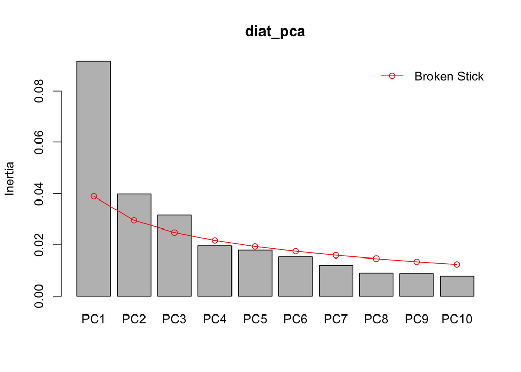

```r
diat_pca |>
  screeplot(bstick = TRUE)
```

We note that the first three axes explain more variance than expected under the null model, but most of this is on the first PCA axis.

Finally, we can plot the data

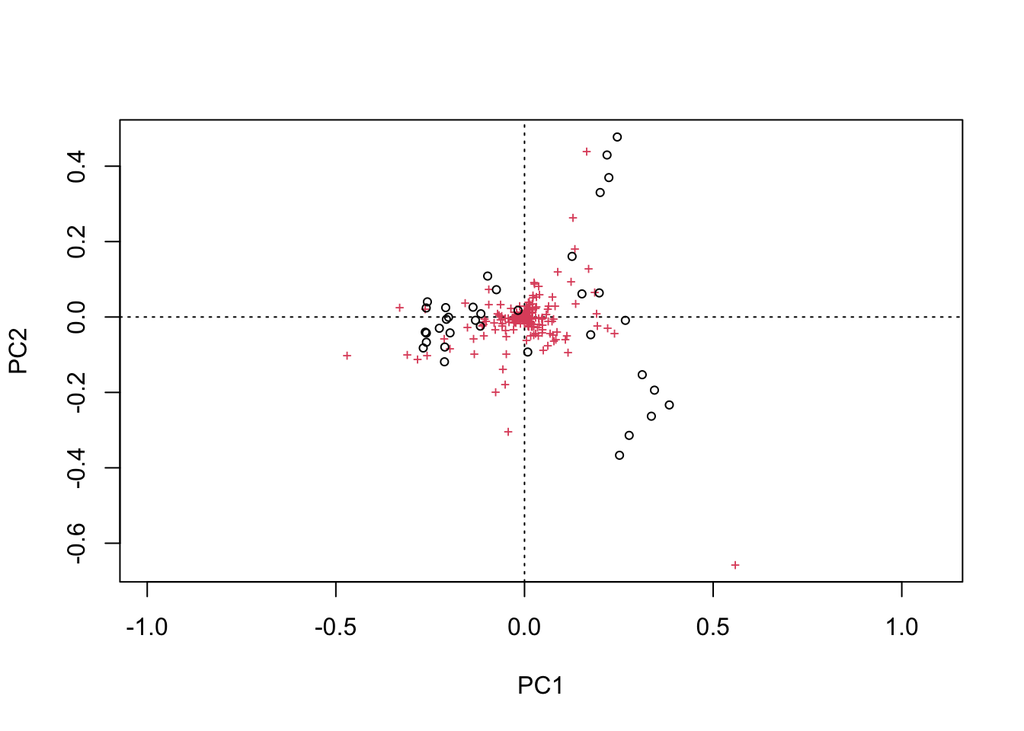

```r
scl <- "symmetric"
diat_pca |> plot(scaling = scl)
```

Here I use the symmetric scaling option as a compromise for a single plot. As there are a large number of taxa here, the `plot()` method will choose to plot the data as points.

To add information to the points, we can use the `ordisurf()` function to look at the temporal trend in the data

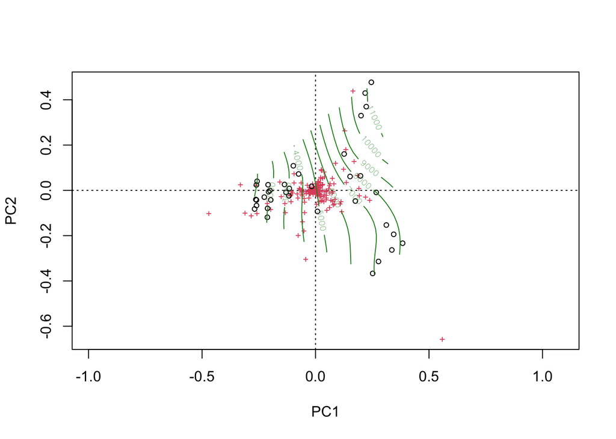

```
##
## Family: gaussian
## Link function: identity
##
## Formula:
## y ~ s(x1, x2, k = 10, bs = "tp", fx = FALSE)
##
## Estimated degrees of freedom:
## 5.91  total = 6.91
##
## REML score: 305.1345
```

```r
diat_pca |> plot(scaling = scl)
ordisurf(
  diat_pca ~ calibrated_age,
  data = diat_meta,
  add = TRUE,
  scaling = scl,
  col = "forestgreen"
)
```

### Correspondence analysis

We can alternatively use a CA to explore these data. We convert to proportions, and then downweight rare taxa before piping the data to `ca()`:

```r
diat_ca <- diat_df |>
  decostand(method = "total") |>
  downweight() |>
  ca()
```

```r
diat_ca
##
## Call: ca(X = downweight(decostand(diat_df, method = "total")))
##
##               Inertia Rank
## Total           1.555
## Unconstrained   1.555   35
##
## Inertia is scaled Chi-square
##
## Eigenvalues for unconstrained axes:
##    CA1    CA2    CA3    CA4    CA5    CA6    CA7    CA8
## 0.3468 0.2040 0.1345 0.1061 0.0864 0.0698 0.0595 0.0540
## (Showing 8 of 35 unconstrained eigenvalues)
```

We note that there are 35 axes (`Rank`), and the eigenvalues are shown for the first eight of these.

To look at the proportions of the variance “explained” by each axis, we use the `eigenvals()` function:

```r
diat_ca |>
  eigenvals() |>
  summary()
## Importance of components:
##                          CA1    CA2     CA3     CA4     CA5     CA6     CA7
## Eigenvalue            0.3468 0.2040 0.13446 0.10606 0.08639 0.06975 0.05948
## Proportion Explained  0.2230 0.1312 0.08644 0.06818 0.05554 0.04484 0.03824
## Cumulative Proportion 0.2230 0.3541 0.44058 0.50877 0.56430 0.60914 0.64739
##                           CA8     CA9    CA10    CA11    CA12    CA13    CA14
## Eigenvalue            0.05403 0.04586 0.04368 0.03904 0.03287 0.03013 0.02855
## Proportion Explained  0.03474 0.02948 0.02808 0.02510 0.02113 0.01937 0.01836
## Cumulative Proportion 0.68212 0.71161 0.73969 0.76478 0.78591 0.80528 0.82364
##                          CA15    CA16    CA17    CA18    CA19    CA20    CA21
## Eigenvalue            0.02695 0.02340 0.02273 0.02095 0.01871 0.01755 0.01641
## Proportion Explained  0.01733 0.01504 0.01461 0.01347 0.01203 0.01129 0.01055
## Cumulative Proportion 0.84096 0.85601 0.87062 0.88409 0.89611 0.90740 0.91795
##                           CA22     CA23     CA24     CA25     CA26     CA27
## Eigenvalue            0.015431 0.012602 0.012381 0.012140 0.010734 0.009605
## Proportion Explained  0.009921 0.008101 0.007959 0.007805 0.006901 0.006175
## Cumulative Proportion 0.927870 0.935971 0.943931 0.951735 0.958636 0.964812
##                           CA28     CA29     CA30     CA31     CA32     CA33
## Eigenvalue            0.009400 0.008541 0.007213 0.006963 0.006621 0.006136
## Proportion Explained  0.006043 0.005491 0.004637 0.004477 0.004256 0.003945
## Cumulative Proportion 0.970855 0.976346 0.980983 0.985459 0.989716 0.993661
##                           CA34     CA35
## Eigenvalue            0.005065 0.004797
## Proportion Explained  0.003256 0.003084
## Cumulative Proportion 0.996916 1.000000
```

Here we see that about 45% of the variance in the data is retained by the first three axes of the CA.

We can plot the eigenvalues as a screeplot, with the broken stick null distribution superimposed using the `screeplot()` function

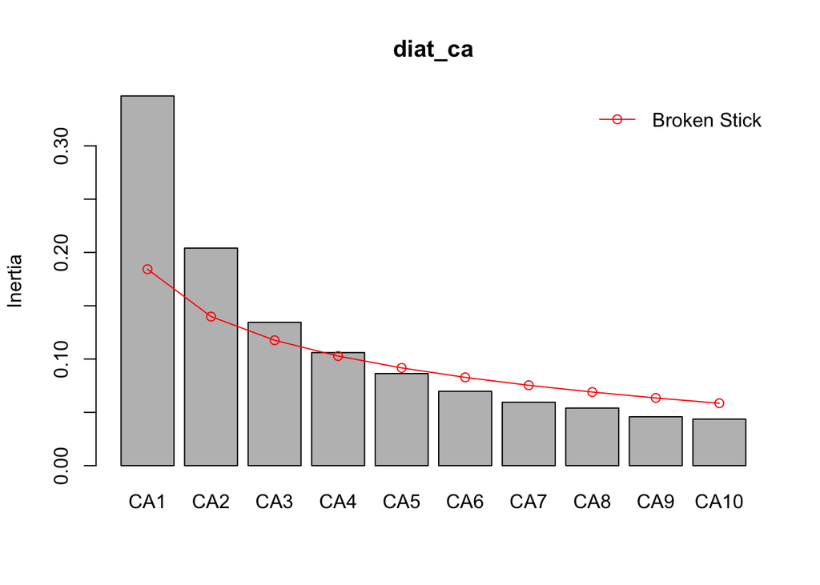

```r
diat_ca |>
  screeplot(bstick = TRUE)
```

We note that the first four axes explain more variance than expected under the null model, but most of this is on the two CA axis. Note however that in CA the eigenvalues are constrained to be $< 1$, so the broken stick model is not quite an appropriate null model.

Finally, we can plot the data

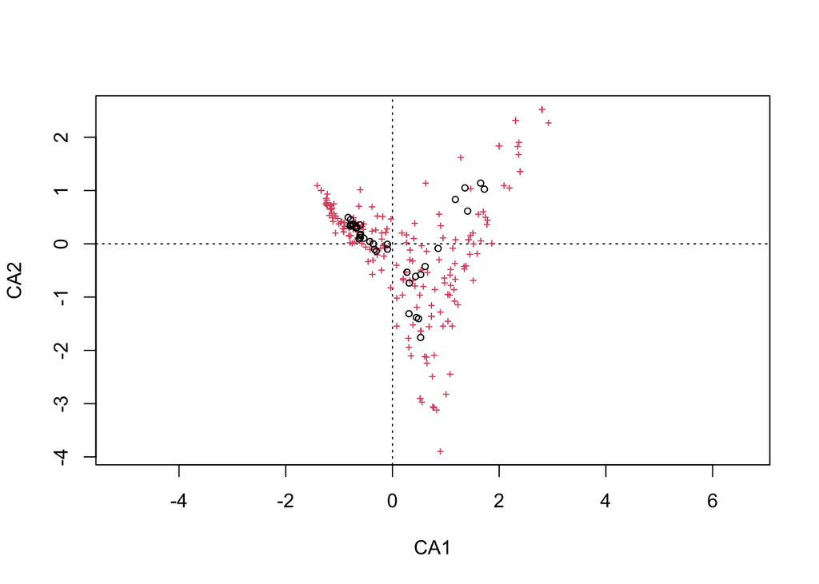

```r
scl <- "symmetric"
diat_ca |> plot(scaling = scl)
```

Here I use the symmetric scaling option as a compromise for a single plot. As there are a large number of taxa here, the `plot()` method will choose to plot the data as points.

To add information to the points, we can use the `ordisurf()` function to look at the temporal trend in the data

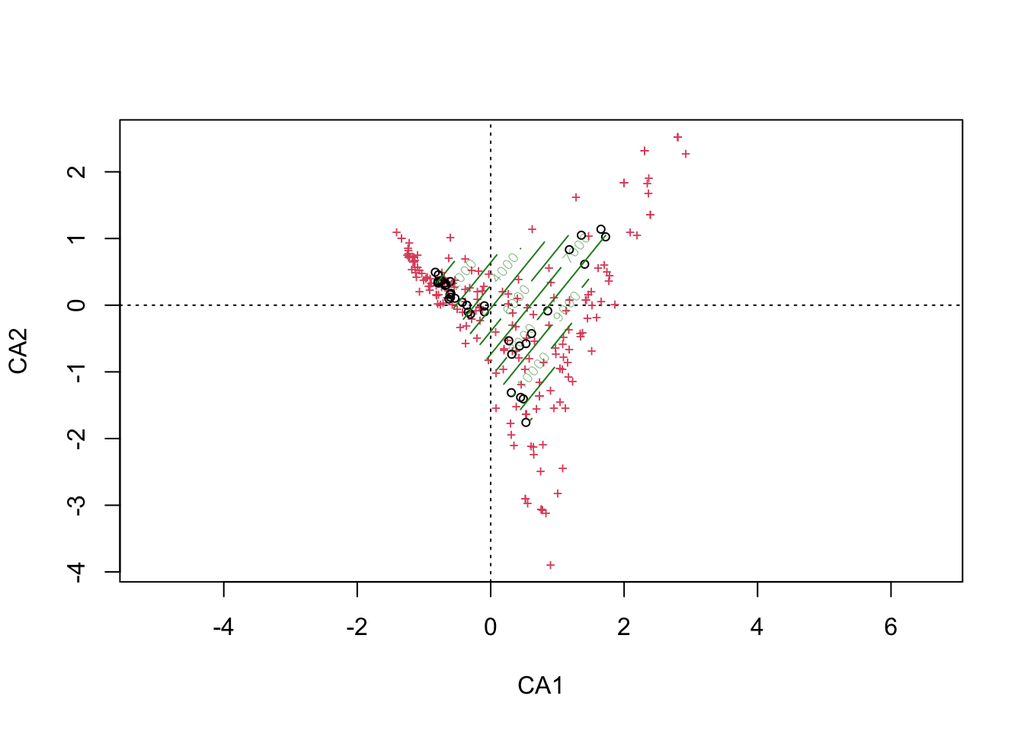

```
##
## Family: gaussian
## Link function: identity
##
## Formula:
## y ~ s(x1, x2, k = 10, bs = "tp", fx = FALSE)
##
## Estimated degrees of freedom:
## 1.99  total = 2.99
##
## REML score: 297.6406
```

```r
diat_ca |> plot(scaling = scl)
ordisurf(
  diat_ca ~ calibrated_age,
  data = diat_meta,
  add = TRUE,
  scaling = scl,
  col = "forestgreen"
)
```

We can zoom in on the points to make a better plot:

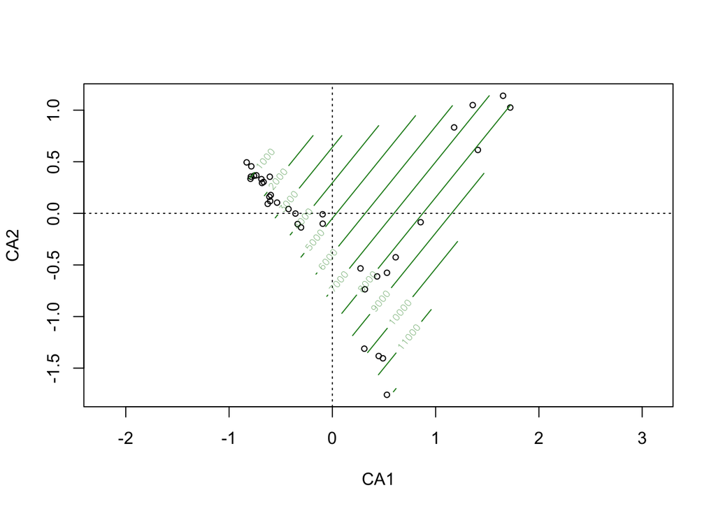

```
##
## Family: gaussian
## Link function: identity
##
## Formula:
## y ~ s(x1, x2, k = 10, bs = "tp", fx = FALSE)
##
## Estimated degrees of freedom:
## 1.99  total = 2.99
##
## REML score: 297.6406
```

```r
diat_ca |>
  plot(scaling = scl, display = "sites", type = "p")
ordisurf(
  diat_ca ~ calibrated_age,
  data = diat_meta,
  add = TRUE,
  scaling = scl,
  display = "sites",
  col = "forestgreen"
)
```

I both analyses, we see, to greater or lesser extent, an arched or curved configuration of the smaples in the ordination. This is likely the result of there being a single dominant gradient (trend) in the diatom data, which for geometric reasons gets bent over multiple axes in the ordination.

**Tip**

If you have time, repeat the PCA or the CA for the chironomid data.

## Cocorrespondence analysis

We’ll compare the diatoms and pollen for the samples that overlap using cocorrespondence analysis (CoCA). To do a CoCA, we need to subset the data to the sample levels that match across the data. Here, I am sinply matching on the numeric depths of the samples being the same and I’m asusming these were done on the same core. An alternative would be match on sample ages, and also to allow some padding (a window) around the depths or ages.

A semi-join is a *filtering* join; it retains the samples from the `diat_meta` data that have a matching `depth_cm` in the `pollen_meta` data:

```r
diat_sub <- diat_meta |> semi_join(
  pollen_meta,
  by = join_by("depth_cm")
)
```

Now that we have the metadata for the samples where we have both diatoms and pollen, we can use a semi-join on the diatom data themselves to filter only those with the retained smaple `identifier`s:

```r
diat_sub_df <- diat_wide |>
  semi_join(
    diat_sub,
    by = join_by(identifier)
  ) |>
  tibble::column_to_rownames("identifier")
```

We repeat this step with the data sets reversed, to retain only those pollen samples with a matching diatom sample:

```r
pollen_sub <- pollen_meta |> semi_join(
  diat_meta,
  by = join_by("depth_cm")
)
```

```r
pollen_sub_df <- pollen_wide |>
  semi_join(
    pollen_sub,
    by = join_by(identifier)
  ) |>
  tibble::column_to_rownames("identifier")
```

As a quick check, let’s make sure that we have two objects with the same number of samples:

```r
all.equal(nrow(diat_sub_df), nrow(pollen_sub_df))
## [1] TRUE
```

This is a minimum of checking that should be done on your data.

Convert to proportions and run the Co-CA. Here we fit a symmetric Co-CA as we do not want one of the taxnomic groups to play the role of predictor and the other the response.

```r
dp_coca <- coca(
  x = diat_sub_df |> decostand(method = "total"),
  y = pollen_sub_df |> decostand(method = "total"),
  method = "symmetric"
)
##
## Removed some species that contained no data in: decostand(pollen_sub_df, method = "total"), decostand(diat_sub_df, method = "total")
```

We can look at how well we explain the covariance between the two taxonomic groups using the `summary()` method

```r
summary(dp_coca)
##
## Symmetric Co-Correspondence Analysis
##
## Call: symcoca(y = y, x = x, n.axes = n.axes, R0 = weights, symmetric =
## symmetric, nam.dat = nam.dat)
##
## Inertia:
##                                              Total Explained Residual
## decostand(pollen_sub_df, method = "total"): 0.7307    0.7307        0
## decostand(diat_sub_df, method = "total"):   1.8524    1.8524        0
##
## Eigenvalues:
##    COCA 1     COCA 2     COCA 3     COCA 4     COCA 5     COCA 6     COCA 7
## 7.592e-02  3.590e-02  7.248e-03  3.340e-03  2.459e-03  1.451e-03  9.100e-04
##    COCA 8     COCA 9    COCA 10    COCA 11    COCA 12    COCA 13    COCA 14
## 5.827e-04  5.610e-04  3.485e-04  3.352e-04  2.414e-04  2.195e-04  1.747e-04
##   COCA 15    COCA 16    COCA 17    COCA 18    COCA 19    COCA 20    COCA 21
## 1.331e-04  1.144e-04  1.001e-04  7.010e-05  6.480e-05  5.371e-05  4.481e-05
##   COCA 22    COCA 23    COCA 24    COCA 25    COCA 26    COCA 27    COCA 28
## 4.103e-05  3.604e-05  3.002e-05  2.553e-05  2.159e-05  1.903e-05  1.610e-05
##   COCA 29    COCA 30    COCA 31    COCA 32
## 1.282e-05  1.109e-05  9.073e-06  4.605e-06
```

Here we note that we have sufficient axes to explain all of the covariance between the two data sets, so our task is to decide how many axes to display. We can look at the correlations between the axis scores for the diatoms and pollen

```r
corAxis(dp_coca)
##    COCA 1    COCA 2    COCA 3    COCA 4    COCA 5    COCA 6    COCA 7    COCA 8
## 0.9416189 0.9202864 0.8884376 0.8972647 0.9057574 0.8792332 0.8751127 0.8927946
##    COCA 9   COCA 10   COCA 11   COCA 12   COCA 13   COCA 14   COCA 15   COCA 16
## 0.8640855 0.8794835 0.7771264 0.9059948 0.8642113 0.8257820 0.8552994 0.8668156
##   COCA 17   COCA 18   COCA 19   COCA 20   COCA 21   COCA 22   COCA 23   COCA 24
## 0.8590280 0.8537927 0.8971488 0.8763465 0.8991841 0.8725447 0.8310841 0.8191330
##   COCA 25   COCA 26   COCA 27   COCA 28   COCA 29   COCA 30   COCA 31   COCA 32
## 0.7748326 0.8787392 0.8438794 0.8883269 0.9005003 0.7674476 0.8454808 0.8759783
```

We can also plot the eigenvalues of the Co-CA in a screeplot, to help decide how many to retain

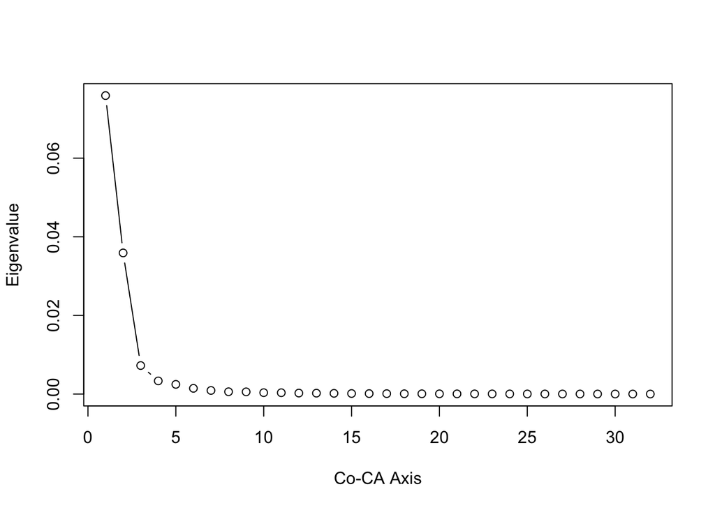

```r
screeplot(dp_coca)
```

Here, we see a marked change in the slope of the screeplot at three Co-CA, indicating that two Co-CA axes describe the structure in the covariances of the diatom and pollen data.

We should expect high correlations as that is what Co-CA is maximising, but we do see that the first two axes are the most strongly correlated. To produce plots of the samples on the first two CoCA axes, we can use

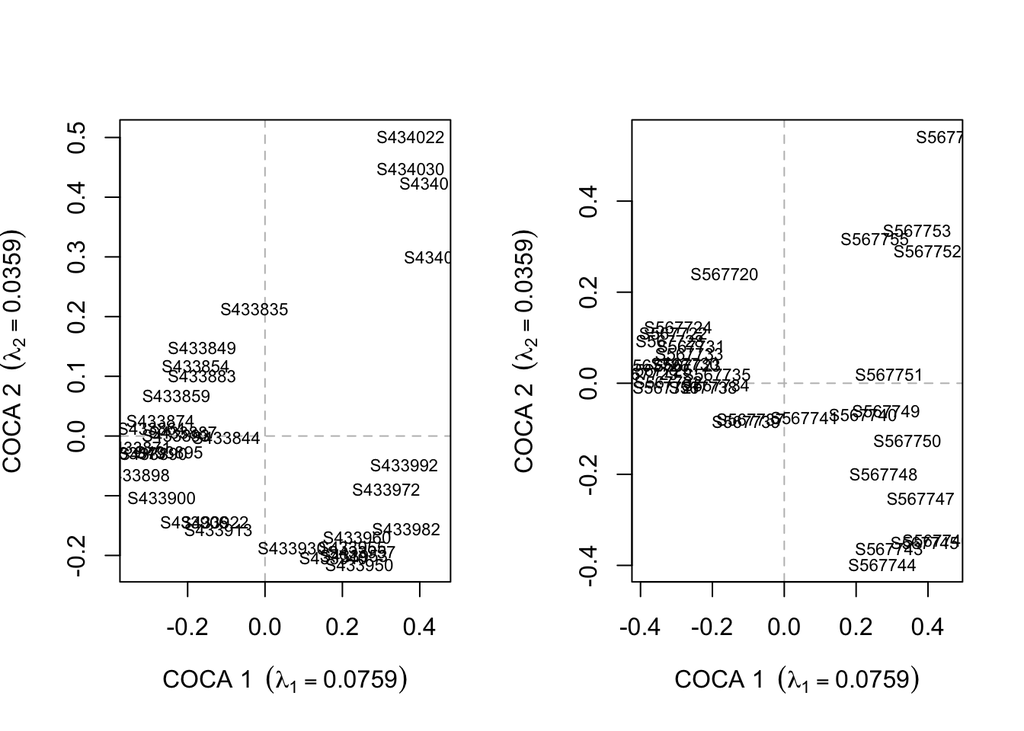

```r
layout(matrix(1:2, ncol = 2))
plot(dp_coca, which = "y1", display = "sites")
plot(dp_coca, which = "y2", display = "sites")
```

```r
layout(1)
```

A similar plot can be produced for the taxa, but we really need to abbreviate the taxon labels to achieve a better plot

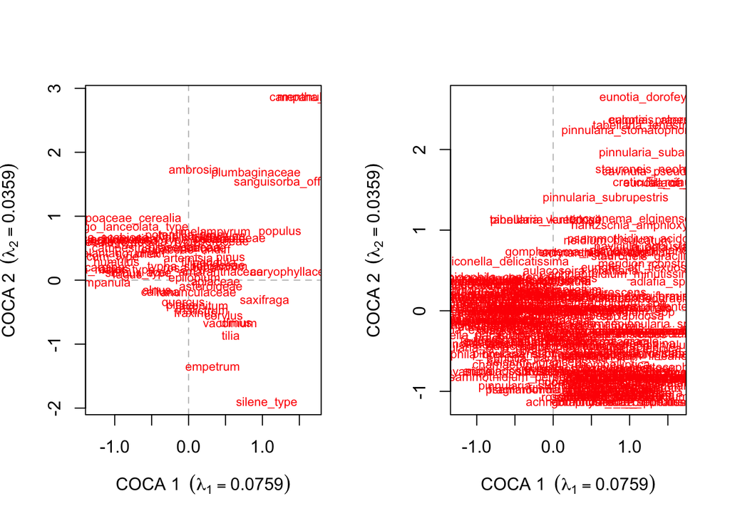

```r
layout(matrix(1:2, ncol = 2))
plot(dp_coca, which = "y1", display = "species", type = "t")
plot(dp_coca, which = "y2", display = "species", type = "t")
```

```r
layout(1)
```

I should note that CoCA ordinations are difficult to plot cleanly, and you will need to exercise your R, *dplyr*, and possibly *ggplot2* skills. If you need help, email me or post in the [Discussions](https://github.com/gavinsimpson/cocorresp/discussions) tab of the GitHub repo for the *cocorresp* package.

**Tip**

If you have time, repeat the Co-Ca code to look at the diatoms and chironomids.

**Note**

You will need to repeat all the code from this section, as the chrionomids and diatoms overlap at fewer samples than the diatoms